# Step [1]: Prepare libraries and data

```python
!pip install arabic-reshaper
```

```python
!pip install tashaphyne
```

```python
!pip install PyArabic
```

```python
!pip install python-bidi
```

```python
!pip install qalsadi
```

```python
!pip install tashaphyne
```

## [1.1] Include important libraries

```python
import re
import csv
import pandas as pd
import numpy as np
import matplotlib.pyplot as plt
import seaborn as sns
import string
import nltk
import collections
import matplotlib
import qalsadi.lemmatizer
import pyarabic
import pyarabic.araby as araby
import tashaphyne.arabic_const as arabconst
from nltk.collocations import BigramCollocationFinder
from nltk.metrics import BigramAssocMeasures
from nltk.corpus import stopwords
from nltk.tokenize import TweetTokenizer
from nltk import word_tokenize
from nltk.corpus import stopwords
from collections import Counter
from wordcloud import WordCloud
from bidi.algorithm import get_display
from arabic_reshaper import reshape
from tashaphyne.stemming import ArabicLightStemmer
```

```python
from keras.layers import Dense, Activation, Dropout, Input, LSTM, Reshape, Lambda, RepeatVector,Bidirectional,GRU
from keras.layers import Dense, LSTM, InputLayer, Bidirectional, TimeDistributed, Embedding, Activation,SpatialDropout1D
```

```python
nltk.download('stopwords')
```

## [1.2] Download data

```python
!wget 'https://drive.google.com/uc?export=download&id=1KepfzAhJ7dloG8XaWQf0ovQipDHYS8aI' -O 'final_data.zip'
```

```python
!unzip final_data.zip
```

## [1.3] read data from csv files

```python
train_data = pd.read_csv('train.csv')
valid_data = pd.read_csv('valid.csv')
test_data  = pd.read_csv('test.csv')
train_data.head()
```

|  | tweet | label |
| --- | --- | --- |
| 0 | #تبني_قطط_انقاذ من الخاص هاااام كيتن أنثى عمره... | 2 |
| 1 | '#خذ_الخطوة_خذ_اللقاح \nالحمدالله من قبل ومن ب... | 1 |
| 2 | لو اللي مثلك وشرواك طعمو كان قد حذفنا الكمامات... | 1 |
| 3 | #الصحة:•نحو 14.5 مليون شخص تم إعطاؤهم جرعة لقا... | 1 |
| 4 | • في منظور القوة البشرية ( الأزمة ستطول لأشهر ... | 3 |

```python
train_data.drop(4597, inplace=True)
```

## [1.4] Prapere The Comparison Dictionary

```python
model_comparison_table = {}
model_comparison_table['model_name'] = []
model_comparison_table['preprocessing_methods'] = []
model_comparison_table['accuracy'] = []
```

# Step [2]: Build Baseline Model

```python
x_train = train_data[(train_data["label"] == 0) | (train_data["label"] == 1)]['tweet'].tolist()
y_train = train_data[(train_data["label"] == 0) | (train_data["label"] == 1)]['label'].tolist()
x_test  = test_data[(test_data["label"] == 0) | (test_data["label"] == 1)]['tweet'].tolist()
y_test  = test_data[(test_data["label"] == 0) | (test_data["label"] == 1)]['label'].tolist()
```

## [2.1] Extract Bag of Words Features

```python
from sklearn.feature_extraction.text import CountVectorizer
# use a BOW model to vectorize the sentences.
def bow_features(X_train, X_test):
    count_vectorizer = CountVectorizer(ngram_range=(1, 2))
    X_train_Vec = count_vectorizer.fit_transform(X_train)
    X_test_Vec = count_vectorizer.transform(X_test)
    return X_train_Vec, X_test_Vec, count_vectorizer.vocabulary_
```

```python
X_train_bag, X_test_bag, bow_vocab = bow_features(x_train,x_test)
```

## [2.2] Train LogisticRegression model with BOW

```python
from sklearn.linear_model import LogisticRegression,RidgeClassifier
def train_classifier(X_train, y_train):
    classifier = LogisticRegression()
    classifier.fit(X_train, y_train)
    return classifier
```

```python
classifier_bag = train_classifier(X_train_bag,y_train)
```

## [2.3] Evaluation

```python
from sklearn.metrics import accuracy_score
y_test_predicted_labels_bag = classifier_bag.predict(X_test_bag)
y_test_predicted_scores_bag = classifier_bag.decision_function(X_test_bag)
print('Bag-of-words Accuracy:  LogisticRegression',accuracy_score(y_test, y_test_predicted_labels_bag))
```

```
Bag-of-words Accuracy:  LogisticRegression 0.7835848362164152
```

```python
model_comparison_table['model_name'].append("logistic regression with bag of words")
model_comparison_table['preprocessing_methods'].append("none")
model_comparison_table['accuracy'].append(accuracy_score(y_test, y_test_predicted_labels_bag))
```

```python
import pandas as pd
df = pd.DataFrame(model_comparison_table)
df
```

|  | model_name | preprocessing_methods | accuracy |
| --- | --- | --- | --- |
| 0 | logistic regression with bag of words | none | 0.783585 |

## [3] Text cleaning and Normalization

## (3-1) Removing Mintions and Links and Photos from text:

```python
my_test_case = train_data.tweet[79] #A tweet with mintion & link & repeated letters
```

```python
def remove_mintions(tweet,work):
  '''
  تنظيف أسماء المستخدمين
  '''
  if work ==1:
    cleaned_tweet = re.sub(r"@\S+",'',tweet)
  else:
    cleaned_tweet = tweet
  return cleaned_tweet
```

```python
def remove_urls(tweet,work):
  '''
  تنظيف الروابط
  '''
  if work ==1:
      cleaned_tweet = re.sub(r"(https|http|ftp)?://\S*.((\S*\S*)|(\S*))",'', tweet)
  else:
    cleaned_tweet = tweet
  return cleaned_tweet
```

```python
'''
There is no duplicate lines
'''
train_data.duplicated().sum()
```

```
0
```

```python
def remove_images(tweet,work):
  '''
  تنظيف الصور
  '''
  if work ==1:
    cleaned_tweet = re.sub(r"pic\.twitter\.com/\S+",'', tweet)
    cleaned_tweet = re.sub("\w+(\.png|\.jpg|\.gif|\.jpeg)", " ", cleaned_tweet)
  else:
    cleaned_tweet = tweet
  return cleaned_tweet
```

لا نقوم بحذف الهاشتاغات لأنها أكثر مايعبر عن محتوى التغريدة وبالتالي الكلمات التي تتبعها ستساعدنا كثيرا في عملية التصنيف لاحقاً

## (3-2) Removing duplicated characters in words:

```python
def  remove_duplicated_char(tweet,work):
  '''
  تنظيف التغريدات من الأحرف المكررة
  '''
  if work ==1:
    cleaned_tweet= re.sub(r'(\w)\1+', r'\1', tweet)
    cleaned_tweet =re.sub(r'(.)\1+', r'\1',cleaned_tweet)

  else:
    cleaned_tweet = tweet
  return cleaned_tweet
```

```python
def  preprocess_tweet(tweet,work):
    '''
     استدعاء توابع التنظيف السابقة جميعها
    '''
    if work== 1:
        cleaned_tweet= remove_urls(tweet,work)
        cleaned_tweet= remove_images(cleaned_tweet,work)
        cleaned_tweet= remove_mintions(cleaned_tweet,work)
        cleaned_tweet= remove_duplicated_char(cleaned_tweet,work)
        return cleaned_tweet
    return tweet
```

```python
def preprocesse(df,work):
    df['cleaned_tweet'] = df['tweet'].apply(lambda x: preprocess_tweet(str(x),work))
    return df
```

## (3-4) Removing digits:

```python
def remove_tweet_digits(tweet,work):
    '''
     تنضيف الترقيم
    '''
    if work ==1:
        cleaned_tweet = re.sub(r'[d]+', r'', tweet)
        cleaned_tweet = re.sub(r'([0-9]*\-[0-9]*)*', '', cleaned_tweet)
    else:
        cleaned_tweet = tweet
    return cleaned_tweet
```

```python
def removing_digits(df, text_field):
  df['cleaned_tweet'] = df[text_field].apply(lambda x: remove_tweet_digits(str(x),1))
  return df
```

من الممكن أن تكون الأرقام مفيدة للدلالة على رقم اللقاح الشائع كما في كلمة (كوفيد-19) أو من معرفة تواريخ تلقي اللقاح كما أنه يفيد في معرفة عدد متلقي اللقاح مما يسهل اجراء تصنيفات اخرى لاحقاُ

## (3-5) Removing Emojies and Punctuation and Stop words:

```python
all_stop_words = set(stopwords.words('arabic'))
```

```python
from nltk.tokenize import TweetTokenizer
tokenizer = TweetTokenizer()
```

```python
def remove_stopword(tweet,work):
    words= " "
    token =tokenizer.tokenize(str(tweet))
    for t in token:
        if t not in all_stop_words:
            words += t + " "
    cleaned_tweet= "".join(words)
    if work ==1:
        cleaned_tweet = words
    else:
        cleaned_tweet = tweet
    return cleaned_tweet
```

```python
def remove_all_stopwords(df,text_field):
    df['cleaned_tweet'] = df[text_field].apply(lambda x: " ".join([w for w in str(x).split() if not w in all_stop_words]))
    return df
```

- الى تغيير معنى الجملة (مثل حذف كلمة "ليس" أو "لا") مما سيؤثر على دقة التصنيف لاحقاًstop wordsمن الممكن أن يؤدي حذف ال

```python
def remove_tweet_emojies(tweet,work):

    """Process tweet function.
    Input:
        tweet: a string containing a tweet without removing Emojies
    Output:
        cleaned_tweet: tweet with removing Emojies
    """
    emoji_pattern = re.compile("["
        u"\U0001F600-\U0001F64F"  # emoticons
        u"\U0001F300-\U0001F5FF"  # symbols & pictographs
        u"\U0001F680-\U0001F6FF"  # transport & map symbols
        u"\U0001F1E0-\U0001F1FF"  # flags (iOS)
        u"\U0001F1F2-\U0001F1F4"  # Macau flag
        u"\U0001F1E6-\U0001F1FF"  # flags
        u"\U0001F600-\U0001F64F"
        u"\U00002702-\U000027B0"
        u"\U000024C2-\U0001F251"
        u"\U0001f926-\U0001f937"
        u"\U0001F1F2"
        u"\U0001F1F4"
        u"\U0001F620"
        u"\u200d"
        u"\u2640-\u2642"
        "]+", flags=re.UNICODE)
    if work ==1:
       cleaned_tweet = emoji_pattern.sub(r'',tweet)
    else:
      cleaned_tweet = tweet

    return cleaned_tweet
```

```python
def remove_all_tweet_emojies(df, text_field):
    df['cleaned_tweet'] = df[text_field].apply(lambda x: remove_tweet_emojies(str(x),1))
    return df
```

- وجود الرموز التعبيرية من الممكن أن يفيد في معرفة نوع التغريدة حيث من الممكن أن تكون العبارة حيادية أو ربما هدفها السخرية من اللقاح علما ان الجملة تحوي معنى إيجابي فوجود الرمز التعبيري هو مايعبر عما اذا كانت داعمة لأخذ اللقاح أم لا

```python
def remove_punctuation(tweet,work):
    if work ==1:
        cleaned_tweet =re.sub('[%s]' % re.escape("""!"#$%&'()*+,،-./:;<=>؟?@[\]^_`{|}~|\•|\)|\("""), ' ', tweet)
    else:
        cleaned_tweet = tweet
    return cleaned_tweet
```

## (3-6) Removing characters and English words:

```python
#remove not arabic word from tweet
def remove_NotArabic_chars(tweet,work):
    """
    Process tweet function.
    Input:
        tweet: a string containing a tweet without changing
    Output:
        cleaned_tweet:A tweet after  remove_NotArabic_chars
    """
    if work ==1:
      cleaned_tweet = re.sub(r'[/(){}\[\]\|]', '', tweet)
      cleaned_tweet = re.sub(r'[!$%^?&*><]', '', cleaned_tweet )
      cleaned_tweet = re.sub(r'[\'\"،—.,;+-=]', '', cleaned_tweet )
      cleaned_tweet = re.sub(r'[\n]', '', cleaned_tweet ) # removing \n
      cleaned_tweet = re.sub(r'\s*[A-Za-z]+\b', '' ,cleaned_tweet )# removing English letters
      cleaned_tweet =re.sub(r"\s+",' ',cleaned_tweet) # remove_extra_white_space
    else:
     cleaned_tweet = tweet
    return cleaned_tweet
```

```python
def remove_all_NotArabic_chars(df, text_field):
    df['cleaned_tweet'] = df[text_field].apply(lambda x: remove_NotArabic_chars(str(x),1))
    return df
```

## (3-7) Lemmatization And stemming Arabic Words:

```python
#استخدام مكتبة لايجاد الجذور للكلمات باللغة العربية
from tashaphyne.stemming import ArabicLightStemmer
import pyarabic.arabrepr
```

```python
def tashaphyne_stemming(tweet,work):
  if work == 1:
    tweet_tokens = tokenizer.tokenize(tweet)
    arepr = pyarabic.arabrepr.ArabicRepr()
    repr = arepr.repr
    ArListem = ArabicLightStemmer()
    output = ""

    for word in tweet_tokens:
        if (word.find("#") == -1): # we dont stemm a hashtag
            stem = ArListem.light_stem(word)
            stem = ArListem.get_stem()
            #print(word + " -> "+ stem)
        else:
            stem = word
        output+=(stem + " ")

    cleaned_tweet= "".join(output)
  else:
    cleaned_tweet = tweet
  return cleaned_tweet
```

```python
def clean2(df, text_field):
    df['cleaned_tweet'] = df[text_field].apply(lambda x: tashaphyne_stemming(str(x),1))
    return df
```

```python
import qalsadi.lemmatizer
def qalsadi_lemmatizer(tweet,work):
    lemmer = qalsadi.lemmatizer.Lemmatizer()
    tweet_tokens = tokenizer.tokenize(tweet)
    if work == 1:
        output = ""
        for word in tweet_tokens:
            if (word.find("#") == -1):  # we dont lemmatize a hashtag
                lemma = lemmer.lemmatize(word)
            else:
                lemma = word
            output+=(lemma + " ")
        cleaned_tweet= "".join(output)
    else:
        cleaned_tweet = tweet

    return cleaned_tweet
```

الهاشتاغات يجب أن لاتجذع ولا تجذر لانه من الممكن كثيرا ان يتغير معنى الكلمة الواردة بعده حيث تحمل المعنى الأكثر أهمية للجملة وذلك واضح من خلال خرج عمليات التجذير السابقة

## (3-8) Characters normalization:

# لمعالجة بعض الاخطاء الاملائية وتقليل عدد كبير من الكلمات المتشابهة ذات نفس المعنى

```python
#  The converted letters are :
#  The converted lettersinto HAMZA are: WAW_HAMZA,YEH_HAMZA
#  The converted lettersinto ALEF are: ALEF_MADDA,
#  ALEF_HAMZA_ABOVE, ALEF_HAMZA_BELOW ,HAMZA_ABOVE, HAMZA_BELOW
def hamza_normalizing(tweet,work):
  if work ==1:
    cleaned_tweet = arabconst.ALEFAT_PAT.sub(arabconst.ALEF, tweet)
    return arabconst.HAMZAT_PAT.sub(arabconst.HAMZA,cleaned_tweet )
  else:
    return tweet
```

```python
#تحويل التاء المربوطة الى هاء والألف المقصورة الى ياء
def spellerrors_normalizing(tweet,work):
  if work ==1:
    cleaned_tweet = re.sub(u'[%s]' % arabconst.TEH_MARBUTA, arabconst.HEH, tweet)
    return re.sub(u'[%s]' % arabconst.ALEF_MAKSURA, arabconst.YEH, cleaned_tweet)
  else:
    return tweet
```

- من أجل توحيد النصوص بشكل أفضل تم اضافة التوابع التالية لإزالة التطوبل والتشكيل من الكلمات

```python
#إزالة التشكيل من الكلمات
def strip_tashkeel(tweet,work):
  if work ==1:
    return arabconst.HARAKAT_PAT.sub('', tweet)
  else:
    return tweet
```

```python
#إزالة التطويل من الكلمات
def strip_tatweel(tweet,work):
  if work ==1:
    return re.sub(u'[%s]'% arabconst.TATWEEL,'', tweet)
  else:
    return tweet
```

```python
def Characters_normalization(text,work):
    if work==1:
        text = hamza_normalizing(text,1)
        text = spellerrors_normalizing(text,1)
        text = strip_tashkeel(text,1)
        text = strip_tatweel(text,1)
        return text
    return text
```

```python
def clean_chars(df, text_field):
    df['cleaned_tweet'] = df[text_field].apply(lambda x: Characters_normalization(str(x),1))
    return df
```

```python
train_data.duplicated().sum()
```

```
0
```

```python
#استدعاء جميع توابع التنظيف
def preprocessing_final(tweet, work):
    """Process tweet function.
    Input:
        tweet: a string containing a tweet
        flags: list of "work" values for all functions will called here.
    Output:
        cleaned_tweet: tweet after apply all cleaning and normlizaing functions

    """
    tweet = re.sub('RT|cc', ' ', tweet)  # remove RT and cc
    tweet = preprocess_tweet(tweet,work)
    tweet = remove_tweet_emojies(tweet, work)
    tweet = remove_punctuation(tweet, work)
    tweet = remove_tweet_digits(tweet, work)
    #tweet = remove_stopword(tweet, work)
    tweet = remove_NotArabic_chars(tweet,work)
    #tweet = tashaphyne_stemming(tweet,work)
    #tweet = qalsadi_lemmatizer(tweet, work)
    tweet = Characters_normalization(tweet,work)
    tweet =re.sub(r"\s+",' ',tweet)
    return tweet
```

```python
train_data.duplicated().sum()
```

```
0
```

```python
def preprocess_final(df, text_field):
    df['cleaned_tweet'] = df[text_field].apply(lambda x: preprocessing_final(str(x),1))
    return df
```

```python
train_data_cleaned = preprocess_final(train_data,'tweet')
test_data_cleaned = preprocess_final(test_data,'tweet')
valid_data_cleaned= preprocess_final(valid_data,'tweet')
```

```python
x_train_cleaned = train_data_cleaned[(train_data_cleaned["label"] == 0) | (train_data_cleaned["label"] == 1)]['cleaned_tweet'].tolist()
y_train = train_data_cleaned[(train_data_cleaned["label"] == 0) | (train_data_cleaned["label"] == 1)]['label'].tolist()
x_test_cleaned = test_data_cleaned[(test_data_cleaned["label"] == 0) | (test_data_cleaned["label"] == 1)]['cleaned_tweet'].tolist()
y_test = test_data_cleaned[(test_data_cleaned["label"] == 0) | (test_data_cleaned["label"] == 1)]['label'].tolist()
```

## [2.2] Train LogisticRegression model with BOW for cleaned Data (0/1):

```python
X_train_cleaned_bag, X_test_cleaned_bag, bow_vocab_cleaned = bow_features(x_train_cleaned,x_test_cleaned)
```

```python
classifier_bag = train_classifier(X_train_cleaned_bag,y_train)
```

```python
y_test_predicted_labels_bag = classifier_bag.predict(X_test_cleaned_bag)
y_test_predicted_scores_bag = classifier_bag.decision_function(X_test_cleaned_bag)
```

```python
from sklearn.metrics import accuracy_score
print('Bag-of-words Accuracy: LogisticRegression ',accuracy_score(y_test, y_test_predicted_labels_bag))
```

[output not shown]

```python
model_comparison_table['model_name'].append("logistic regression with bag of words")
model_comparison_table['preprocessing_methods'].append("All axcept removing stop words & stemm & lemma")
model_comparison_table['accuracy'].append(accuracy_score(y_test, y_test_predicted_labels_bag))
```

```python
import pandas as pd
df = pd.DataFrame(model_comparison_table)
df
```

|  | model_name | preprocessing_methods | accuracy |
| --- | --- | --- | --- |
| 0 | logistic regression with bag of words | none | 0.783585 |
| 1 | logistic regression with bag of words | All axcept removing stop words & stemm & lemma | 0.783585 |

## [2.2] Train LogisticRegression model with Tfidf for cleaned Data (0/1):

```python
from sklearn.feature_extraction.text import TfidfVectorizer
def tfidf_features(X_train, X_test):

    tfidf_vectorizer = TfidfVectorizer(min_df = 1, max_df = 0.6, ngram_range=(1, 2))
    X_train = tfidf_vectorizer.fit_transform(X_train)
    X_test = tfidf_vectorizer.transform(X_test)

    return X_train, X_test, tfidf_vectorizer.vocabulary_,tfidf_vectorizer
```

**تم ضبط معاملات ال TfidfVectorizerملاحظة: عن طريق التجريب اليدوي حيث كانت دقة عند هذه المعاملات مناسبة**

min_df = 1, max_df = 0.6, ngram_range=(1, 2) ^^

```python
X_train_tfidf, X_test_tfidf, tfidf_vocab,tfidf_vectorizer = tfidf_features(x_train_cleaned, x_test_cleaned)
```

```python
classifier_tfidf = train_classifier(X_train_tfidf, y_train)
```

```python
y_test_predicted_labels_tfidf = classifier_tfidf.predict(X_test_tfidf)
y_test_predicted_scores_tfidf = classifier_tfidf.decision_function(X_test_tfidf)
```

```python
print('Tfidf Accuracy: LogisticRegression ' ,accuracy_score(y_test, y_test_predicted_labels_tfidf))
```

```
Tfidf Accuracy: LogisticRegression  0.7732793522267206
```

```python
model_comparison_table['model_name'].append("logistic regression with tfidf")
model_comparison_table['preprocessing_methods'].append("All axcept removing stop words & stemm & lemma")
model_comparison_table['accuracy'].append(accuracy_score(y_test, y_test_predicted_labels_tfidf))
```

```python
import pandas as pd
df = pd.DataFrame(model_comparison_table)
df
```

|  | model_name | preprocessing_methods | accuracy |
| --- | --- | --- | --- |
| 0 | logistic regression with bag of words | none | 0.783585 |
| 1 | logistic regression with bag of words | All axcept removing stop words & stemm & lemma | 0.783585 |
| 2 | logistic regression with tfidf | All axcept removing stop words & stemm & lemma | 0.773279 |

## [4] Train Ridge Classifier model ^^

```python
def train_ridge_classifier(X_train, y_train):
    classifier = RidgeClassifier()
    classifier.fit(X_train, y_train)
    return classifier
```

RidgeClassifier with BOW for uncleaned data(0/1):

```python
ridge_classifier_bag = train_ridge_classifier(X_train_bag,y_train)
```

```python
y_test_predicted_ridge_labels_bag =ridge_classifier_bag.predict(X_test_bag)
y_test_predicted_ridge_scores_bag = ridge_classifier_bag.decision_function(X_test_bag)
```

```python
print('Bag-of-words Accuracy: RidgeClassifier',accuracy_score(y_test, y_test_predicted_ridge_labels_bag))
```

```
Bag-of-words Accuracy: RidgeClassifier 0.7872653662127347
```

```python
model_comparison_table['model_name'].append("Ridge Classifier with BOW")
model_comparison_table['preprocessing_methods'].append("None")
model_comparison_table['accuracy'].append(accuracy_score(y_test, y_test_predicted_ridge_labels_bag))
```

```python
df = df.loc[:,~df.columns.duplicated()]
```

```python
import pandas as pd
df = pd.DataFrame(model_comparison_table)
df
```

|  | model_name | preprocessing_methods | accuracy |
| --- | --- | --- | --- |
| 0 | logistic regression with bag of words | none | 0.783585 |
| 1 | logistic regression with bag of words | All axcept removing stop words & stemm & lemma | 0.783585 |
| 2 | logistic regression with tfidf | All axcept removing stop words & stemm & lemma | 0.773279 |
| 3 | Ridge Classifier with BOW | None | 0.787265 |

**Ridge Classifier with bow for cleaned data(0/1):**

```python
X_train_cleaned_bag, X_test_cleaned_bag, bow_vocab_cleaned = bow_features(x_train_cleaned,x_test_cleaned)
```

```python
ridge_classifier_bag = train_ridge_classifier(X_train_cleaned_bag,y_train)
```

```python
y_test_predicted_ridge_labels_bag =ridge_classifier_bag.predict(X_test_cleaned_bag)
y_test_predicted_ridge_scores_bag = ridge_classifier_bag.decision_function(X_test_cleaned_bag)
```

```python
print('Bag-of-words Accuracy: RidgeClassifier ',accuracy_score(y_test, y_test_predicted_ridge_labels_bag))
```

[output not shown]

```python
model_comparison_table['model_name'].append("Ridge Classifier with BOW")
model_comparison_table['preprocessing_methods'].append("All axcept removing stop words & stemm & lemma")
model_comparison_table['accuracy'].append(accuracy_score(y_test, y_test_predicted_ridge_labels_bag))
```

```python
import pandas as pd
df = pd.DataFrame(model_comparison_table)
df
```

|  | model_name | preprocessing_methods | accuracy |
| --- | --- | --- | --- |
| 0 | logistic regression with bag of words | none | 0.783585 |
| 1 | logistic regression with bag of words | All axcept removing stop words & stemm & lemma | 0.783585 |
| 2 | logistic regression with tfidf | All axcept removing stop words & stemm & lemma | 0.773279 |
| 3 | Ridge Classifier with BOW | None | 0.787265 |
| 4 | Ridge Classifier with BOW | All axcept removing stop words & stemm & lemma | 0.787265 |

RidgeClassifier with tfidf for cleaned data(0/1):

```python
ridge_classifier_tfidf =train_ridge_classifier(X_train_tfidf, y_train)
```

```python
y_test_predicted_ridge_labels_tfidf = ridge_classifier_tfidf.predict(X_test_tfidf)
y_test_predicted_ridge_scores_tfidf = ridge_classifier_tfidf.decision_function(X_test_tfidf)
```

```python
print('Tfidf Accuracy: RidgeClassifier' ,accuracy_score(y_test, y_test_predicted_ridge_labels_tfidf))
```

```
Tfidf Accuracy: RidgeClassifier 0.8001472211998528
```

```python
model_comparison_table['model_name'].append("RidgeClassifier with Tfidf")
model_comparison_table['preprocessing_methods'].append("All axcept removing stop words & stemm & lemma")
model_comparison_table['accuracy'].append(accuracy_score(y_test, y_test_predicted_ridge_labels_tfidf))
```

```python
import pandas as pd
df = pd.DataFrame(model_comparison_table)
df
```

|  | model_name | preprocessing_methods | accuracy |
| --- | --- | --- | --- |
| 0 | logistic regression with bag of words | none | 0.783585 |
| 1 | logistic regression with bag of words | All axcept removing stop words & stemm & lemma | 0.783585 |
| 2 | logistic regression with tfidf | All axcept removing stop words & stemm & lemma | 0.773279 |
| 3 | Ridge Classifier with BOW | None | 0.787265 |
| 4 | Ridge Classifier with BOW | All axcept removing stop words & stemm & lemma | 0.787265 |
| 5 | RidgeClassifier with Tfidf | All axcept removing stop words & stemm & lemma | 0.800147 |

```python
import pandas as pd

model_comparison_table['model_name'].append("logistic regression with BOW")
model_comparison_table['preprocessing_methods'].append("remove urls")
model_comparison_table['accuracy'].append("0.791682")
df = pd.DataFrame(model_comparison_table)

model_comparison_table['model_name'].append("logistic regression with BOW")
model_comparison_table['preprocessing_methods'].append("reome urls& images")
model_comparison_table['accuracy'].append("0.791682")
df = pd.DataFrame(model_comparison_table)

model_comparison_table['model_name'].append("logistic regression with BOW")
model_comparison_table['preprocessing_methods'].append("reove urls & images & mintions")
model_comparison_table['accuracy'].append("0.790210")
df = pd.DataFrame(model_comparison_table)

model_comparison_table['model_name'].append("logistic regression with BOW")
model_comparison_table['preprocessing_methods'].append("remove urls & images & mintions & digits")
model_comparison_table['accuracy'].append("0.790210")
df = pd.DataFrame(model_comparison_table)

model_comparison_table['model_name'].append("logistic regression with BOW")
model_comparison_table['preprocessing_methods'].append("remove urls & images 7 mintions, digits, repeated chars")
model_comparison_table['accuracy'].append("0.790210")
df = pd.DataFrame(model_comparison_table)

model_comparison_table['model_name'].append("logistic regression with BOW")
model_comparison_table['preprocessing_methods'].append("remove urls, images, mintions, digits, repeated chars, stemming")
model_comparison_table['accuracy'].append("0.784626")
df = pd.DataFrame(model_comparison_table)

model_comparison_table['model_name'].append("logistic regression with BOW")
model_comparison_table['preprocessing_methods'].append("remove urls, images, mintions, digits, repeated chars, limmatization")
model_comparison_table['accuracy'].append("0.785804")
df = pd.DataFrame(model_comparison_table)

model_comparison_table['model_name'].append("ogistic regression with BOW")
model_comparison_table['preprocessing_methods'].append("urls, images, mintions, digits, repeated chars, stopwords")
model_comparison_table['accuracy'].append("0.790210")
df = pd.DataFrame(model_comparison_table)
```

```python
df
```

|  | model_name | preprocessing_methods | accuracy |
| --- | --- | --- | --- |
| 0 | logistic regression with bag of words | none | 0.783585 |
| 1 | logistic regression with bag of words | All axcept removing stop words & stemm & lemma | 0.783585 |
| 2 | logistic regression with tfidf | All axcept removing stop words & stemm & lemma | 0.773279 |
| 3 | Ridge Classifier with BOW | None | 0.787265 |
| 4 | Ridge Classifier with BOW | All axcept removing stop words & stemm & lemma | 0.787265 |
| 5 | RidgeClassifier with Tfidf | All axcept removing stop words & stemm & lemma | 0.800147 |
| 6 | logistic regression with BOW | remove urls | 0.791682 |
| 7 | logistic regression with BOW | reome urls& images | 0.791682 |
| 8 | logistic regression with BOW | reove urls & images & mintions | 0.790210 |
| 9 | logistic regression with BOW | remove urls & images & mintions & digits | 0.790210 |
| 10 | logistic regression with BOW | remove urls & images 7 mintions, digits, repea... | 0.790210 |
| 11 | logistic regression with BOW | remove urls, images, mintions, digits, repeate... | 0.784626 |
| 12 | logistic regression with BOW | remove urls, images, mintions, digits, repeate... | 0.785804 |
| 13 | ogistic regression with BOW | urls, images, mintions, digits, repeated chars... | 0.790210 |

```python
import matplotlib.pyplot as plt
plt.style.use('ggplot')

def plot_history(history):
    acc = history.history['accuracy']
    val_acc = history.history['val_accuracy']
    loss = history.history['loss']
    val_loss = history.history['val_loss']
    x = range(1, len(acc) + 1)

    plt.figure(figsize=(12, 5))
    plt.subplot(1, 2, 1)
    plt.plot(x, acc, 'b', label='Training acc')
    plt.plot(x, val_acc, 'r', label='Validation acc')
    plt.title('Training and validation accuracy')
    plt.legend()
    plt.subplot(1, 2, 2)
    plt.plot(x, loss, 'b', label='Training loss')
    plt.plot(x, val_loss, 'r', label='Validation loss')
    plt.title('Training and validation loss')
    plt.legend()
```

```python
x_train_cleaned = train_data_cleaned[(train_data_cleaned["label"] == 0) | (train_data_cleaned["label"] == 1)]['cleaned_tweet']
y_train_cleaned = train_data_cleaned[(train_data_cleaned["label"] == 0) | (train_data_cleaned["label"] == 1)]['label']
x_test_cleaned = test_data_cleaned[(test_data_cleaned["label"] == 0) | (test_data_cleaned["label"] == 1)]['cleaned_tweet']
y_test_cleaned = test_data_cleaned[(test_data_cleaned["label"] == 0) | (test_data_cleaned["label"] == 1)]['label']
x_valid_cleaned = valid_data_cleaned[(valid_data_cleaned["label"] == 0) | (valid_data_cleaned["label"] == 1)]['cleaned_tweet']
y_valid_cleaned = valid_data_cleaned[(valid_data_cleaned["label"] == 0) | (valid_data_cleaned["label"] == 1)]['label']
```

**5-Deep Neural Networks for Text Classification**

```python
from keras.preprocessing.text import Tokenizer
from keras.models import Sequential
from keras import layers
#بيعطيني index لكل كلمة بعبر عن الاكثر تكرار
tokenizer = Tokenizer(num_words=5000)
tokenizer.fit_on_texts(x_train_cleaned )

X_train = tokenizer.texts_to_sequences(x_train_cleaned )
X_test = tokenizer.texts_to_sequences(x_test_cleaned)
X_vlaid = tokenizer.texts_to_sequences(x_valid_cleaned)


vocab_size = len(tokenizer.word_index) + 1  # Adding 1 because of reserved 0 index
print(x_train[2])
print(X_train[2])
```

```
#الصحة:•نحو 14.5 مليون شخص تم إعطاؤهم جرعة لقاح #كورونا•اللقاحات آمنة وبإمكان كل من تلقى اللقاح التبرع بالدم•يمكن تلقي جرعات مختلفة من لقاح كورونا
[14, 739, 50, 77, 49, 4231, 29, 1, 2, 66, 379, 27, 3, 55, 5, 3636, 143, 55, 74, 1052, 3, 1, 2]
```

```python
from keras.preprocessing.sequence import pad_sequences

maxlen = 100

X_train = pad_sequences(X_train, padding='post', maxlen=maxlen)
X_test = pad_sequences(X_test, padding='post', maxlen=maxlen)
X_valid = pad_sequences(X_vlaid, padding='post', maxlen=maxlen)
```

```python
from keras.backend import clear_session
clear_session()
```

## 5-1 -Deep Neural Networks with word embedding & Keras Embedding Layer:

```python
from keras.models import Sequential
from keras import layers

embedding_dim = 32

model = Sequential()
model.add(layers.Embedding(input_dim=vocab_size, output_dim=embedding_dim, input_length=maxlen))
model.add(layers.Flatten())
model.add(layers.Dense(16, activation='relu'))
model.add(layers.Dense(1, activation='sigmoid'))
model.compile(optimizer='adam',
              loss='binary_crossentropy',
              metrics=['accuracy'])
model.summary()
```

```
Model: "sequential"
_________________________________________________________________
 Layer (type)                Output Shape              Param #
=================================================================
 embedding (Embedding)       (None, 100, 32)           982880

 flatten (Flatten)           (None, 3200)              0

 dense (Dense)               (None, 16)                51216

 dense_1 (Dense)             (None, 1)                 17

=================================================================
Total params: 1,034,113
Trainable params: 1,034,113
Non-trainable params: 0
_________________________________________________________________
```

```python
from keras.callbacks import EarlyStopping

EarlyStopping(monitor='val_err', patience=5)
```

```
<keras.callbacks.EarlyStopping at 0x7f9bed7912d0>
```

```
Training Accuracy: 0.9949
Testing Accuracy:  0.7670
```

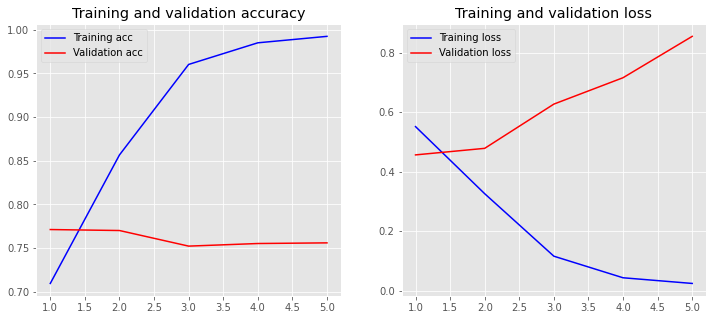

```python
history = model.fit(X_train, y_train_cleaned,epochs=5,verbose=True,validation_data=(X_valid, y_valid_cleaned),batch_size=10)
loss, accuracy = model.evaluate(X_train, y_train_cleaned, verbose=False)
print("Training Accuracy: {:.4f}".format(accuracy))
loss, accuracy = model.evaluate(X_test, y_test_cleaned, verbose=False)
print("Testing Accuracy:  {:.4f}".format(accuracy))
plot_history(history)
```

```python
model_comparison_table['model_name'].append("Deep Neural Networks with word embedding & Keras Embedding Layer:")
model_comparison_table['preprocessing_methods'].append("All axcept removing stop words & stemm & lemma")
model_comparison_table['accuracy'].append("Train Acc:0.9949 Test Acc:0.7670")
df = pd.DataFrame(model_comparison_table)
```

```python
df
```

|  | model_name | preprocessing_methods | accuracy |
| --- | --- | --- | --- |
| 0 | logistic regression with bag of words | none | 0.783585 |
| 1 | logistic regression with bag of words | All axcept removing stop words & stemm & lemma | 0.783585 |
| 2 | logistic regression with tfidf | All axcept removing stop words & stemm & lemma | 0.773279 |
| 3 | Ridge Classifier with BOW | None | 0.787265 |
| 4 | Ridge Classifier with BOW | All axcept removing stop words & stemm & lemma | 0.787265 |
| 5 | RidgeClassifier with Tfidf | All axcept removing stop words & stemm & lemma | 0.800147 |
| 6 | logistic regression with BOW | remove urls | 0.791682 |
| 7 | logistic regression with BOW | reome urls& images | 0.791682 |
| 8 | logistic regression with BOW | reove urls & images & mintions | 0.790210 |
| 9 | logistic regression with BOW | remove urls & images & mintions & digits | 0.790210 |
| 10 | logistic regression with BOW | remove urls & images 7 mintions, digits, repea... | 0.790210 |
| 11 | logistic regression with BOW | remove urls, images, mintions, digits, repeate... | 0.784626 |
| 12 | logistic regression with BOW | remove urls, images, mintions, digits, repeate... | 0.785804 |
| 13 | ogistic regression with BOW | urls, images, mintions, digits, repeated chars... | 0.790210 |
| 14 | Deep Neural Networks with word embedding & Ker... | All axcept removing stop words & stemm & lemma | Train Acc:0.9949 Test Acc:0.7670 |

```python
from keras.backend import clear_session
clear_session()
```

## 5-2 -CNN Model:Reduce Overfitting With Dropout Regularization in Keras

```python
embedding_dim = 32
model1 = Sequential()
model1.add(layers.Embedding(vocab_size, embedding_dim, input_length=maxlen))
model1.add(layers.Conv1D(16, 5, activation='relu'))
model1.add(Dropout(0.5))
model1.add(layers.GlobalMaxPooling1D())
model1.add(Dropout(0.5))
model1.add(layers.Dense(10, activation='relu'))
model1.add(Dropout(0.5))
model1.add(layers.Dense(1, activation='sigmoid'))
model1.compile(optimizer='adam',
              loss='binary_crossentropy',
              metrics=['accuracy'])
model1.summary()
```

```
Model: "sequential"
_________________________________________________________________
 Layer (type)                Output Shape              Param #
=================================================================
 embedding (Embedding)       (None, 100, 32)           982880

 conv1d (Conv1D)             (None, 96, 16)            2576

 dropout (Dropout)           (None, 96, 16)            0

 global_max_pooling1d (Globa  (None, 16)               0
 lMaxPooling1D)

 dropout_1 (Dropout)         (None, 16)                0

 dense (Dense)               (None, 10)                170

 dropout_2 (Dropout)         (None, 10)                0

 dense_1 (Dense)             (None, 1)                 11

=================================================================
Total params: 985,637
Trainable params: 985,637
Non-trainable params: 0
_________________________________________________________________
```

```
Training Accuracy: 0.9266
Testing Accuracy:  0.7714
```

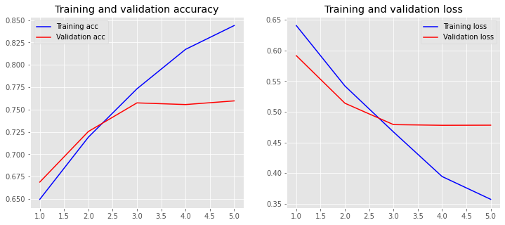

```python
history1 = model1.fit(X_train, y_train_cleaned,epochs=5,verbose=True,validation_data=(X_valid, y_valid_cleaned),batch_size=10)
loss, accuracy = model1.evaluate(X_train, y_train_cleaned, verbose=False)
print("Training Accuracy: {:.4f}".format(accuracy))
loss, accuracy = model1.evaluate(X_test, y_test_cleaned, verbose=False)
print("Testing Accuracy:  {:.4f}".format(accuracy))
plot_history(history1)
```

```python
model_comparison_table['model_name'].append("CNN Model:Reduce Overfitting With Dropout Regularization:")
model_comparison_table['preprocessing_methods'].append("All axcept removing stop words & stemm & lemma")
model_comparison_table['accuracy'].append("Train_Acc:0.9266 Test_Acc:0.7714")
df = pd.DataFrame(model_comparison_table)
```

```python
df
```

|  | model_name | preprocessing_methods | accuracy |
| --- | --- | --- | --- |
| 0 | logistic regression with bag of words | none | 0.783585 |
| 1 | logistic regression with bag of words | All axcept removing stop words & stemm & lemma | 0.783585 |
| 2 | logistic regression with tfidf | All axcept removing stop words & stemm & lemma | 0.773279 |
| 3 | Ridge Classifier with BOW | None | 0.787265 |
| 4 | Ridge Classifier with BOW | All axcept removing stop words & stemm & lemma | 0.787265 |
| 5 | RidgeClassifier with Tfidf | All axcept removing stop words & stemm & lemma | 0.800147 |
| 6 | logistic regression with BOW | remove urls | 0.791682 |
| 7 | logistic regression with BOW | reome urls& images | 0.791682 |
| 8 | logistic regression with BOW | reove urls & images & mintions | 0.790210 |
| 9 | logistic regression with BOW | remove urls & images & mintions & digits | 0.790210 |
| 10 | logistic regression with BOW | remove urls & images 7 mintions, digits, repea... | 0.790210 |
| 11 | logistic regression with BOW | remove urls, images, mintions, digits, repeate... | 0.784626 |
| 12 | logistic regression with BOW | remove urls, images, mintions, digits, repeate... | 0.785804 |
| 13 | ogistic regression with BOW | urls, images, mintions, digits, repeated chars... | 0.790210 |
| 14 | Deep Neural Networks with word embedding & Ker... | All axcept removing stop words & stemm & lemma | Train Acc:0.9949 Test Acc:0.7670 |
| 15 | CNN Model:Reduce Overfitting With Dropout Regu... | All axcept removing stop words & stemm & lemma | Train_Acc:0.9266 Test_Acc:0.7714 |

**ملاحظة: تم تجريب العديد من الحلول لحل مشكلة الأوفر فيتينغ في شبكة ال cnn لكن بسبب تعقيدها وزيادة عدد ال trainable parameter** لم نستطع التخلص منها نهائيا Dropout Regularizationبال

```python
from keras.backend import clear_session
clear_session()
```

**5-3 Sequence classification with LSTM:** تم ضبط برمترات هذه الشبكة عن طريق ال gridsearch grid = RandomizedSearchCV() وذلك للحصول على أفضل دقة

```python
from keras.backend import clear_session
clear_session()
```

```python
model2 = Sequential()
model2.add(Embedding(len(tokenizer.index_word)+1, 128))
model2.add(LSTM(32, dropout=0, recurrent_dropout=0))#LSTM(32)
model2.add(Dense(32, activation='relu'))
model2.add(Dense(1, activation='sigmoid'))
model2.summary()
# Compile the model
model2.compile(optimizer='adam',
              loss='binary_crossentropy',
              metrics=['accuracy'])
```

```
Model: "sequential_1"
_________________________________________________________________
 Layer (type)                Output Shape              Param #
=================================================================
 embedding_1 (Embedding)     (None, None, 128)         3931520

 lstm_1 (LSTM)               (None, 32)                20608

 dense_2 (Dense)             (None, 32)                1056

 dense_3 (Dense)             (None, 1)                 33

=================================================================
Total params: 3,953,217
Trainable params: 3,953,217
Non-trainable params: 0
_________________________________________________________________
```

```
Training Accuracy: 0.7001
Testing Accuracy:  0.6522
```

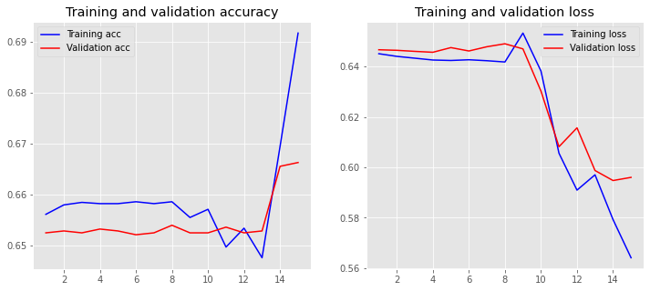

```python
history2 = model2.fit(X_train, y_train_cleaned,epochs=15,verbose=True,validation_data=(X_valid, y_valid_cleaned),batch_size=10)
loss, accuracy = model2.evaluate(X_train, y_train_cleaned, verbose=False)
print("Training Accuracy: {:.4f}".format(accuracy))
loss, accuracy = model2.evaluate(X_test, y_test_cleaned, verbose=False)
print("Testing Accuracy:  {:.4f}".format(accuracy))
plot_history(history2)
```

```python
model_comparison_table['model_name'].append("Sequence classification Model with LSTM:")
model_comparison_table['preprocessing_methods'].append("All axcept removing stop words & stemm & lemma")
model_comparison_table['accuracy'].append("Train_Acc:0.7001 Test_Acc:0.6522")
df = pd.DataFrame(model_comparison_table)
```

```python
from keras.backend import clear_session
clear_session()
```

**##5-4 keras.layers.recurrent.GRU Model**

```python
model5 = Sequential()
model5.add(layers.Embedding(vocab_size,64))
model5.add(GRU(units=32, activation='tanh'))
model5.add(Dense(32, activation='relu'))
model5.add(Dropout(0.2))
model5.add(Dense(1, activation='sigmoid'))
model5.summary()
    # Compile the model
model5.compile(optimizer='adam',
              loss='binary_crossentropy',
              metrics=['accuracy'])
```

[output not shown]

```
Training Accuracy: 0.7324
Testing Accuracy:  0.7067
```

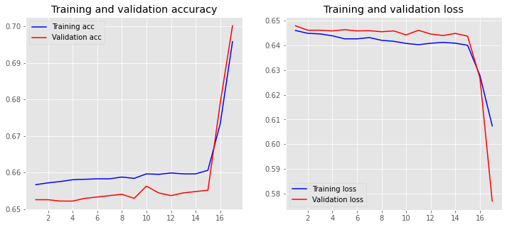

```python
history5 = model5.fit(X_train, y_train_cleaned,epochs=17,verbose=True,validation_data=(X_valid, y_valid_cleaned),batch_size=10)
loss, accuracy = model5.evaluate(X_train, y_train_cleaned, verbose=False)
print("Training Accuracy: {:.4f}".format(accuracy))
loss, accuracy = model5.evaluate(X_test, y_test_cleaned, verbose=False)
print("Testing Accuracy:  {:.4f}".format(accuracy))
plot_history(history5)
```

```python
model_comparison_table['model_name'].append("GRU Model:")
model_comparison_table['preprocessing_methods'].append("All axcept removing stop words & stemm & lemma")
model_comparison_table['accuracy'].append("Train_Acc:0.7324 Test_Acc:0.7067")
df = pd.DataFrame(model_comparison_table)
```

```python
df
```

|  | model_name | preprocessing_methods | accuracy |
| --- | --- | --- | --- |
| 0 | logistic regression with bag of words | none | 0.783585 |
| 1 | logistic regression with bag of words | All axcept removing stop words & stemm & lemma | 0.783585 |
| 2 | logistic regression with tfidf | All axcept removing stop words & stemm & lemma | 0.773279 |
| 3 | Ridge Classifier with BOW | None | 0.787265 |
| 4 | Ridge Classifier with BOW | All axcept removing stop words & stemm & lemma | 0.787265 |
| 5 | RidgeClassifier with Tfidf | All axcept removing stop words & stemm & lemma | 0.800147 |
| 6 | logistic regression with BOW | remove urls | 0.791682 |
| 7 | logistic regression with BOW | reome urls& images | 0.791682 |
| 8 | logistic regression with BOW | reove urls & images & mintions | 0.790210 |
| 9 | logistic regression with BOW | remove urls & images & mintions & digits | 0.790210 |
| 10 | logistic regression with BOW | remove urls & images 7 mintions, digits, repea... | 0.790210 |
| 11 | logistic regression with BOW | remove urls, images, mintions, digits, repeate... | 0.784626 |
| 12 | logistic regression with BOW | remove urls, images, mintions, digits, repeate... | 0.785804 |
| 13 | ogistic regression with BOW | urls, images, mintions, digits, repeated chars... | 0.790210 |
| 14 | Deep Neural Networks with word embedding & Ker... | All axcept removing stop words & stemm & lemma | Train Acc:0.9949 Test Acc:0.7670 |
| 15 | CNN Model:Reduce Overfitting With Dropout Regu... | All axcept removing stop words & stemm & lemma | Train_Acc:0.9266 Test_Acc:0.7714 |
| 16 | Sequence classification Model with LSTM: | All axcept removing stop words & stemm & lemma | Train_Acc:0.7001 Test_Acc:0.6522 |
| 17 | GRU Model: | All axcept removing stop words & stemm & lemma | Train_Acc:0.7324 Test_Acc:0.7067 |

**##Hyperparameters Optimization**

```python
#تم ضبط برمترات Sequence classification with LSTM: االموديل الذي تم اعتماده لتدريب كافة الكلاسات في اللطلب الأخير
def create_model(num_Lstm,embedding_dim):
    model3 = Sequential()
    model3.add(Embedding(len(tokenizer.index_word)+1, embedding_dim))#32
    model3.add(LSTM(num_Lstm, dropout=0, recurrent_dropout=0))#32 64 100
    model3.add(Dense(num_Lstm, activation='relu'))
    model3.add(Dense(1, activation='sigmoid'))
    model3.summary()
    # Compile the model
    model3.compile(optimizer='adam',
              loss='binary_crossentropy',
              metrics=['accuracy'])
    return model3
```

```python
from keras.wrappers.scikit_learn import KerasClassifier
from sklearn.model_selection import RandomizedSearchCV
# Main settings
epochs = 20
#embedding_dim = 50
maxlen = 10
output_file = 'data/output.txt'

x_train_cleaned = train_data_cleaned[(train_data_cleaned["label"] == 0) | (train_data_cleaned["label"] == 1)]['cleaned_tweet']
y_train_cleaned = train_data_cleaned[(train_data_cleaned["label"] == 0) | (train_data_cleaned["label"] == 1)]['label']
x_test_cleaned = test_data_cleaned[(test_data_cleaned["label"] == 0) | (test_data_cleaned["label"] == 1)]['cleaned_tweet']
y_test_cleaned = test_data_cleaned[(test_data_cleaned["label"] == 0) | (test_data_cleaned["label"] == 1)]['label']

# Tokenize words
tokenizer = Tokenizer(num_words=5000)
tokenizer.fit_on_texts(x_train_cleaned )
X_train = tokenizer.texts_to_sequences(x_train_cleaned )
X_test = tokenizer.texts_to_sequences(x_test_cleaned )

# Adding 1 because of reserved 0 index
vocab_size = len(tokenizer.word_index) + 1

# Pad sequences with zeros
X_train = pad_sequences(X_train, padding='post', maxlen=maxlen)
X_test = pad_sequences(X_test, padding='post', maxlen=maxlen)

# Parameter grid for grid search  64, 100 ,50,60
param_grid = dict(num_Lstm=[32,64],
                  embedding_dim=[32,50],)

model = KerasClassifier(build_fn=create_model,
                            epochs=epochs, batch_size=10,
                            verbose=False)

grid = RandomizedSearchCV(estimator=model, param_distributions=param_grid,
                              cv=4, verbose=1, n_iter=5)

grid_result = grid.fit(X_train, y_train)

# Evaluate testing set
test_accuracy = grid.score(X_test, y_test)
print(grid_result.best_score_)
print(grid_result.best_params_)
print(test_accuracy)
# Save and evaluate results
s = ('Running {} data set\nBest Accuracy : '
'{:.4f}\n{}\nTest Accuracy : {:.4f}\n\n')
```

[output not shown]

```python
from keras.backend import clear_session
clear_session()
```

## **[6] Train Sequence classification with LSTM Model: (All Classes)**

```python
x_train_cleaned_all = train_data_cleaned["cleaned_tweet"]
y_train_all =train_data_cleaned["label"]
x_test_cleaned_all = test_data_cleaned["cleaned_tweet"]
y_test_all = test_data_cleaned["label"]
x_valid_cleaned_all = valid_data_cleaned["cleaned_tweet"]
y_valid_cleaned_all = valid_data_cleaned["label"]
```

```python
tokenizer = Tokenizer(num_words=5000)
tokenizer.fit_on_texts(x_train_cleaned_all)
X_train_all= tokenizer.texts_to_sequences(x_train_cleaned_all)
X_test_all= tokenizer.texts_to_sequences(x_test_cleaned_all)
X_valid_all= tokenizer.texts_to_sequences(x_valid_cleaned_all)
vocab_size = len(tokenizer.word_index) + 1  # Adding 1 because of reserved 0 index

maxlen = 100
X_train_all = pad_sequences(X_train_all, padding='post', maxlen=maxlen)
X_test_all = pad_sequences(X_test_all, padding='post', maxlen=maxlen)
X_valid_all = pad_sequences(X_valid_all, padding='post', maxlen=maxlen)
```

```python
model_all = Sequential()
model_all.add(Embedding(vocab_size,64))
model_all.add(LSTM(32, dropout=0.2, recurrent_dropout=0))
model_all.add(Dense(32, activation='relu'))
model_all.add(Dense(4, activation='sigmoid'))
model_all.summary()
model_all.compile(optimizer='adam',loss='sparse_categorical_crossentropy',metrics=['accuracy'])
```

```
Model: "sequential"
_________________________________________________________________
 Layer (type)                Output Shape              Param #
=================================================================
 embedding (Embedding)       (None, None, 64)          3347904

 lstm (LSTM)                 (None, 32)                12416

 dense (Dense)               (None, 32)                1056

 dense_1 (Dense)             (None, 4)                 132

=================================================================
Total params: 3,361,508
Trainable params: 3,361,508
Non-trainable params: 0
_________________________________________________________________
```

```
Training Accuracy: 0.6573
Testing Accuracy:  0.4966
```

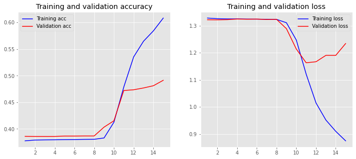

```python
history_all = model_all.fit(X_train_all, y_train_all,epochs=15,verbose=True,validation_data=(X_valid_all, y_valid_cleaned_all),batch_size=10)
loss, accuracy = model_all.evaluate(X_train_all, y_train_all, verbose=False)
print("Training Accuracy: {:.4f}".format(accuracy))
loss, accuracy = model_all.evaluate(X_test_all, y_test_all, verbose=False)
print("Testing Accuracy:  {:.4f}".format(accuracy))
plot_history(history_all)
```

```python
model_comparison_table['model_name'].append("all classes LSTM Model")
model_comparison_table['preprocessing_methods'].append("All axcept removing stop words & stemm & lemma")
model_comparison_table['accuracy'].append("Train_Acc:0.6573 Test_Acc:0.4966")
df = pd.DataFrame(model_comparison_table)
```

```python
df
```

|  | model_name | preprocessing_methods | accuracy |
| --- | --- | --- | --- |
| 0 | logistic regression with bag of words | none | 0.783585 |
| 1 | logistic regression with bag of words | All axcept removing stop words & stemm & lemma | 0.783585 |
| 2 | logistic regression with tfidf | All axcept removing stop words & stemm & lemma | 0.773279 |
| 3 | Ridge Classifier with BOW | None | 0.787265 |
| 4 | Ridge Classifier with BOW | All axcept removing stop words & stemm & lemma | 0.787265 |
| 5 | RidgeClassifier with Tfidf | All axcept removing stop words & stemm & lemma | 0.800147 |
| 6 | logistic regression with BOW | remove urls | 0.791682 |
| 7 | logistic regression with BOW | reome urls& images | 0.791682 |
| 8 | logistic regression with BOW | reove urls & images & mintions | 0.790210 |
| 9 | logistic regression with BOW | remove urls & images & mintions & digits | 0.790210 |
| 10 | logistic regression with BOW | remove urls & images 7 mintions, digits, repea... | 0.790210 |
| 11 | logistic regression with BOW | remove urls, images, mintions, digits, repeate... | 0.784626 |
| 12 | logistic regression with BOW | remove urls, images, mintions, digits, repeate... | 0.785804 |
| 13 | ogistic regression with BOW | urls, images, mintions, digits, repeated chars... | 0.790210 |
| 14 | Deep Neural Networks with word embedding & Ker... | All axcept removing stop words & stemm & lemma | Train Acc:0.9949 Test Acc:0.7670 |
| 15 | CNN Model:Reduce Overfitting With Dropout Regu... | All axcept removing stop words & stemm & lemma | Train_Acc:0.9266 Test_Acc:0.7714 |
| 16 | Sequence classification Model with LSTM: | All axcept removing stop words & stemm & lemma | Train_Acc:0.7001 Test_Acc:0.6522 |
| 17 | GRU Model: | All axcept removing stop words & stemm & lemma | Train_Acc:0.7324 Test_Acc:0.7067 |
| 18 | all classes LSTM Model | All axcept removing stop words & stemm & lemma | Train_Acc:0.6573 Test_Acc:0.4966 |

```python
from keras.backend import clear_session
clear_session()
```

## Imbalanced Data -> balanced Data manually for all classess to getting best acc

```python
df_train= train_data_cleaned.copy(deep=True)
### Separate the majority and minority classes
df_0 = df_train[df_train['label']==0]
df_1= df_train[df_train['label']==1]
df_2= df_train[df_train['label']==2]
df_3= df_train[df_train['label']==3]
### Now, downsamples majority labels equal to the number of samples in the minority class

df_1 = df_1.sample(len(df_0), random_state=0)
df_2 = df_2.sample(len(df_1), random_state=0)
df_3 = df_3.sample(len(df_2), random_state=0)

### concat the majority and minority dataframes
df_train = pd.concat([df_3,df_2,df_1,df_0])

## Shuffle the dataset to prevent the model from getting biased by similar samples
df_train= df_train.sample(frac=1, random_state=0)
labels = list(df_train["label"])
fdist = nltk.FreqDist(w for w in labels)
print (fdist.items())
```

```
dict_items([(2, 2783), (1, 2783), (0, 2783), (3, 2783)])
```

```python
from keras.preprocessing.text import Tokenizer
from keras.models import Sequential
from keras import layers
#بيعطيني index لكل كلمة بعبر عن الاكثر تكرار
tokenizer = Tokenizer(num_words=5000)

df_x= df_train["cleaned_tweet"]
tokenizer.fit_on_texts(df_x)
df_X_test= test_data_cleaned['cleaned_tweet']
df_X_vlaid = valid_data_cleaned['cleaned_tweet']

df_X_train = tokenizer.texts_to_sequences(df_x)
df_X_test = tokenizer.texts_to_sequences(df_X_test)
df_X_vlaid = tokenizer.texts_to_sequences(df_X_vlaid )


vocab_size = len(tokenizer.word_index) + 1  # Adding 1 because of reserved 0 index
```

```python
from keras.preprocessing.sequence import pad_sequences
maxlen = 100

X_train_df = pad_sequences(df_X_train, padding='post', maxlen=maxlen)
X_test_df = pad_sequences(df_X_test, padding='post', maxlen=maxlen)
X_valid_df = pad_sequences(df_X_vlaid, padding='post', maxlen=maxlen)

y_valid_cleaned_df = valid_data_cleaned['label']
y_train_df =df_train["label"]
y_test_df =test_data_cleaned['label']
```

```python
model_bal = Sequential()
model_bal.add(Embedding(vocab_size,128))
model_bal.add(LSTM(64, dropout=0.1, recurrent_dropout=0))
model_bal.add(Dense(64, activation='relu'))
model_bal.add(Dense(4, activation='sigmoid'))
model_bal.summary()
model_bal.compile(optimizer='adam',loss='sparse_categorical_crossentropy',metrics=['accuracy'])
```

```
Model: "sequential_2"
_________________________________________________________________
 Layer (type)                Output Shape              Param #
=================================================================
 embedding_2 (Embedding)     (None, None, 128)         5013632

 lstm_2 (LSTM)               (None, 64)                49408

 dense_4 (Dense)             (None, 64)                4160

 dense_5 (Dense)             (None, 4)                 260

=================================================================
Total params: 5,067,460
Trainable params: 5,067,460
Non-trainable params: 0
_________________________________________________________________
```

**ملاحظة: لم تتحسن دقة الموديل في حالة موازنة الداتا لجميع الأصناف**

```python
history_bal = model_bal.fit(X_train_df,y_train_df,epochs=15,verbose=True,validation_data=(X_valid_df, y_valid_cleaned_df),batch_size=10)
loss, accuracy = model_bal.evaluate(X_train_df,y_train_df, verbose=False)
print("Training Accuracy: {:.4f}".format(accuracy))
loss, accuracy = model_bal.evaluate(X_test_df,y_test_df, verbose=False)
print("Testing Accuracy:  {:.4f}".format(accuracy))
plot_history(history_bal)
```

[output not shown]

```python
df.to_csv("[وسام السحلي].csv", index=False)
```

```python
import pandas as pd

df = pd.DataFrame(model_comparison_table)
df
```

|  | model_name | preprocessing_methods | accuracy |
| --- | --- | --- | --- |
| 0 | logistic regression with bag of words | none | 0.783585 |
| 1 | logistic regression with bag of words | All axcept removing stop words & stemm & lemma | 0.783585 |
| 2 | logistic regression with tfidf | All axcept removing stop words & stemm & lemma | 0.773279 |
| 3 | Ridge Classifier with BOW | None | 0.787265 |
| 4 | Ridge Classifier with BOW | All axcept removing stop words & stemm & lemma | 0.787265 |
| 5 | RidgeClassifier with Tfidf | All axcept removing stop words & stemm & lemma | 0.800147 |
| 6 | logistic regression with BOW | remove urls | 0.791682 |
| 7 | logistic regression with BOW | reome urls& images | 0.791682 |
| 8 | logistic regression with BOW | reove urls & images & mintions | 0.790210 |
| 9 | logistic regression with BOW | remove urls & images & mintions & digits | 0.790210 |
| 10 | logistic regression with BOW | remove urls & images 7 mintions, digits, repea... | 0.790210 |
| 11 | logistic regression with BOW | remove urls, images, mintions, digits, repeate... | 0.784626 |
| 12 | logistic regression with BOW | remove urls, images, mintions, digits, repeate... | 0.785804 |
| 13 | ogistic regression with BOW | urls, images, mintions, digits, repeated chars... | 0.790210 |
| 14 | Deep Neural Networks with word embedding & Ker... | All axcept removing stop words & stemm & lemma | Train Acc:0.9949 Test Acc:0.7670 |
| 15 | CNN Model:Reduce Overfitting With Dropout Regu... | All axcept removing stop words & stemm & lemma | Train_Acc:0.9266 Test_Acc:0.7714 |
| 16 | Sequence classification Model with LSTM: | All axcept removing stop words & stemm & lemma | Train_Acc:0.7001 Test_Acc:0.6522 |
| 17 | GRU Model: | All axcept removing stop words & stemm & lemma | Train_Acc:0.7324 Test_Acc:0.7067 |
| 18 | all classes LSTM Model | All axcept removing stop words & stemm & lemma | Train_Acc:0.6573 Test_Acc:0.4966 |